# Presentation

Dylan Sun

2017-02-14

# Study Design

- Two-site, three-arm, allegiance-controlled randomized clinical tria
- 230 individual subjects, with 94$\%$ females and 6$\%$ males.
- Blocks of 18 patients; block broken into three groups of six
- Eight sessions in eight weeks; each session different
- Pain measured at three time points V2, V3, V4
- 36 missing pain values out of 690 pain measurements

# Objectives

1. Test that EET and CBT are more effective in reducing pain levels than the control treatment EDU
2. See if the new EET therapy is more effective than the standard CBT therapy.

# Homogeneity between treatment groups

- Variables were stratified by treatment
- Compared using chi-squared tests if categorical and one-way anova if continuous.

# Descriptive table

|  | level | EDU | CBT | EET | p |
| --- | --- | --- | --- | --- | --- |
| n |  | 76 | 75 | 79 |  |
| Therapy site (%) | UM | 31 (40.8) | 32 (42.7) | 38 (48.1) | 0.634 |
|  | WSU | 45 (59.2) | 43 (57.3) | 41 (51.9) |  |
| Number of sessions (mean (sd)) |  | 6.46 (1.65) | 5.93 (2.09) | 6.51 (1.85) | 0.114 |
| Age (mean (sd)) |  | 50.28 (12.48) | 48.13 (12.54) | 48.98 (11.70) | 0.552 |
| Years after diagnosis (mean (sd)) |  | 7.36 (8.19) | 8.84 (7.62) | 8.86 (8.08) | 0.426 |
| Sex (%) | 1 | 75 (98.7) | 68 (90.7) | 73 (92.4) | 0.094 |
|  | 2 | 1 ( 1.3) | 7 ( 9.3) | 6 ( 7.6) |  |
| BMI (mean (sd)) |  | 31.46 (6.37) | 30.16 (7.71) | 29.16 (6.64) | 0.121 |
| Ethnic (%) | 1 | 4 ( 5.3) | 2 ( 2.7) | 2 ( 2.6) | 0.601 |
|  | 2 | 72 (94.7) | 71 (97.3) | 76 (97.4) |  |
| Race (%) | 1 | 0 ( 0.0) | 1 ( 1.3) | 1 ( 1.3) | 0.361 |
|  | 3 | 1 ( 1.3) | 0 ( 0.0) | 0 ( 0.0) |  |
|  | 4 | 18 (23.7) | 15 (20.0) | 8 (10.1) |  |
|  | 5 | 54 (71.1) | 57 (76.0) | 68 (86.1) |  |
|  | 6 | 3 ( 3.9) | 2 ( 2.7) | 2 ( 2.5) |  |
| Has health insurance (%) | 0 | 9 (11.8) | 9 (12.0) | 4 ( 5.1) | 0.244 |
|  | 1 | 67 (88.2) | 66 (88.0) | 75 (94.9) |  |
| tp total (mean (sd)) |  | 14.75 (2.53) | 14.63 (3.00) | 14.69 (2.77) | 0.963 |
| acr fmness (mean (sd)) |  | 20.57 (4.73) | 20.34 (4.73) | 20.96 (4.36) | 0.713 |
| CMSI Total (mean (sd)) |  | 38.76 (12.86) | 34.00 (11.72) | 37.31 (11.74) | 0.050 |
| Pain at time V2 (mean (sd)) |  | 5.47 (1.74) | 5.35 (1.62) | 5.34 (1.55) | 0.863 |
| Pain at time V3 (mean (sd)) |  | 5.26 (1.69) | 4.74 (1.66) | 4.42 (2.04) | 0.019 |
| Pain at time V4 (mean (sd)) |  | 4.86 (1.97) | 4.83 (1.69) | 4.49 (2.20) | 0.462 |
| Pain difference V2-V4 (mean (sd)) |  | 0.63 (1.92) | 0.57 (1.55) | 0.80 (1.62) | 0.713 |

# Normality

- For the anovas

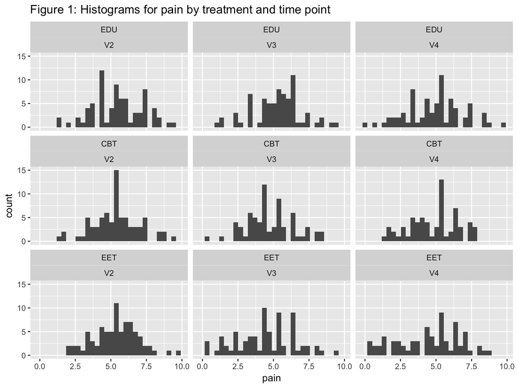

# Grouping

- Collapsed on group level with mean pain level within each group at each time point;
- 120 observations (40 groups with 3 measurements each)
- Missing pain values were omitted for mean.
- Deal with the missing values and missed treatments
- Each group goes through all eight sessions together and is bonded

# Model

- Outcome variable: group pain
- Covariates: measurement time, interaction between measurement time and treatment type as the covariates
- Measurement time and treatment type treated as categorical
- Only three measurement times, with large, uneven timespans between them
- Assume that baseline pain measurements are equal between the treatment arms
- Random slope

# Model results

| Variable | Value | Std.Error | p-value |
| --- | --- | --- | --- |
| timeV3 | -0.22 | 0.22 | 0.30 |
| timeV4 | -0.58 | 0.24 | 0.02 |
| timeV2*CBT | -0.10 | 0.30 | 0.75 |
| timeV3*CBT | -0.56 | 0.32 | 0.09 |
| timeV4*CBT | -0.12 | 0.41 | 0.77 |
| timeV2*EET | -0.13 | 0.29 | 0.66 |
| timeV3*EET | -0.90 | 0.31 | 0.01 |
| timeV4*EET | -0.41 | 0.40 | 0.30 |

72 degrees freedom

# Model diagnostics

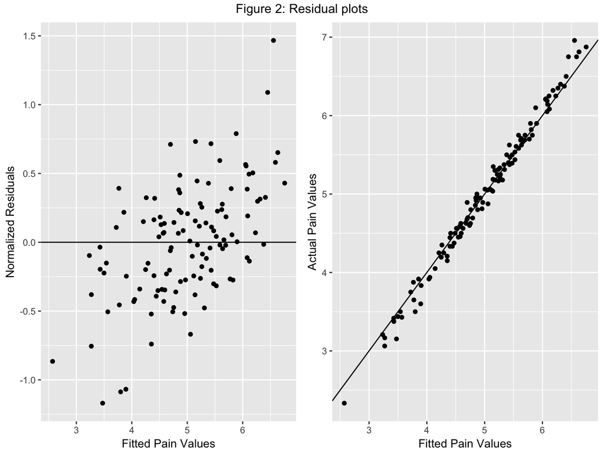

# Conclusions